# Time Series Modelling

### Time Series Models with multiple predictor variables. Estimating Beta coefficients by using the best OLS model-[maximizing R-square/ adjusted R-square/ minimizing Akaike/BIC values ].

### ‘AIC’,‘BIC’,‘Forward stepwise’,‘Backward stepwise’,‘Lasso’,‘Combination’,‘Kitchen Sink’,‘PM’

```r
# Loading packages
library(rJava)
library(xlsx)
library(glmnet)
```

```r
# Define OLS Function
OLS <- function(X0,y0,varargin){
  # t(x0) is transpose of X0
  Beta = solve(t(X0)%*%X0)%*%t(X0)%*%y0
  yhat = X0%*%Beta        # fitted y
  nobs = nrow(X0)
  nreg = ncol(X0)
  res = y0-yhat                          #Residuals
  shat = sum(res^2)/(nobs-nreg)          #variance of residuals
  varcovar = shat*solve(t(X0)%*%X0)      #var-covar matrix
  tstat = Beta/ sqrt(diag(varcovar))
  ESS = sum(res^2)
  TSS = sum((y-mean(y))^2)
  Rq = 1-ESS/TSS                         #Rq
  stilda = ESS/(nobs-(nreg-1)-1)
  S2 = (TSS)/(nobs-1)
  Rqad = 1-stilda/S2                               #Rqadj (maximize)
  Aic = log((ESS/nobs))+(2*nreg)/nobs              #Akaike (minimize)
  Bic = log((ESS/nobs))+nreg*log(nobs)/nobs        #Bic    (minimize)
  HQ = log((ESS/nobs))+2*nreg*log(log(nobs))/nobs  #HQ     (minimize)

  S = list(Beta,yhat,tstat,res,shat,varcovar,Rq,Rqad,Aic,Bic,HQ)
  names(S) = c('Beta','yhat','tstat','res','varRes','varcovarBeta','Rq','Rqadj','Akaike','Bic','HQ')

  S
}
```

```r
# Define Forecasts2K
Forecasts2K <- function(X0,y0,Xfor0){
  # This function generates all possible 2^K forecasts using a TxK matrix of
  # predictors, X, and a Tx1 univariate dependent variable, y
  # Note the timing: X(t-1,:), y(t), Xfor(t,:) go in each row
  # X does not contain an intercept, but an intercept is always included in the
  # regression

  Nvar = ncol(X0)  #number of X-variables
  # Say for 3 independent x variables - there are 8 possibilities of inclusion or exclusion of vars.

  AllModels = as.matrix(expand.grid(data.frame(rbind(numeric(Nvar),numeric(Nvar)+1))))  # all permutations of X-variables
  Criteria = matrix(NaN,nrow(AllModels),2)
  AllF = rep(NaN,nrow(AllModels))
  intercept = rep(1,length(y0)) # 119
  nmodels = nrow(AllModels)      #number of models; will return 8 for 3 independent variables

  for (j in 1:nmodels) {
    ## For all possible models find which independent var will have a positive coefficient in the model
    model = which((AllModels[j,])!=0)

    REG = OLS(cbind(intercept,X0[,model]),y0)
    Criteria[j,1] = REG$Akaike
    Criteria[j,2] = REG$Bic
    AllF[j] = t(c(1,Xfor0[model]))%*% REG$Beta
  }
  S = list(AllF,Criteria)
  names(S) = c('AllF','Criteria')
  S
}
```

```r
# Reading Data
datas = read.xlsx('Goyal_Welch_data.xlsx',1,colIndex = 1:20)
temp =sapply(datas, is.nan)
datas = as.matrix(datas)
nrow(datas)
```

```
## [1] 1068
```

```r
X = datas[seq(1,nrow(datas)),c(6:15)] # use data across all years and 10 predictor variables
y = datas[seq(1,nrow(datas)),5]      # Dependent Variables
estimationEnd = 516 #% amount of data to use for initial forecast, 43 years -> 1927 until 1969 here
TT = nrow(X) # sample size
```

```r
modelLabels = c('Data','AIC','BIC','Forward stepwise','Backward stepwise','Lasso','Combination','Kitchen Sink','PM')

AICforecast = matrix(0,TT-estimationEnd,1)
BICforecast = matrix(0,TT-estimationEnd,1)
forwardStepForecast = matrix(0,TT-estimationEnd,1)
backStepForecast = matrix(0,TT-estimationEnd,1)
lassoForecast = matrix(0,TT-estimationEnd,1)
combinationForecast = matrix(0,TT-estimationEnd,1)
kitchenSink = matrix(0,TT-estimationEnd,1)
prevailingMean = matrix(0,TT-estimationEnd,1)

predictors.model.lasso = matrix(0,TT-estimationEnd,10)
```

```r
for (tt in seq(estimationEnd,TT-1)) {

  # say when tt <- 516 (1969-m12)
  # print(TT-tt)    #display how many iterations are left to track progress, estimation should take several minutes
  # X[1:(tt-1),] is 1927-m01 until 1969-m11 all predictor variable values
  # y[2:tt] is 1927-m02 until 1969-m12 dependent variable values. Note a lag is created for the dependent variable
  # X[tt,] is 1969-m12 all predictor variable values
  # 2^10 =1024 different models are possible with 10 predictor variables
  # forecasts creates a matrix of 1024*1
  # criteria creates a matrix of 1024*2
  forecasts = Forecasts2K(X[1:(tt-1),],y[2:tt],X[tt,])$AllF     #constructs forecasts from every combination of predictors
  criteria = Forecasts2K(X[1:(tt-1),],y[2:tt],X[tt,])$Criteria  # holds AIC/Akaike and BIC values for each model
  # Remember lower BIC values the better model
  minIndices = apply(criteria,2,which.min)                      # Apply BIC criteria and select the minimum from the different models created - for each iteration different model implies #of models based on # of predictor variables. 10 in this case
  cv = cv.glmnet(X[1:(tt-1),],y[2:tt],nfolds = 10)           #estimate a LASSO regression and keep one with lowest MSE using 10-fold cross-validation
  # coef(cv,s='lambda.min') will return a 11*1 matrix along with the coefficient values for each variables(10) + intercept corresponding to the lowest lambda value
  # !=0 check will return true /false if or not the coefficents are zero
  # -1 to get rid of the intercept
  IndexMinMSE = (as.vector(coef(cv,s='lambda.min'))!=0)[-1]
  bLasso = numeric(ncol(X)+1)
  # Training set will take only those predictor values which are True in IndexMinMSE(i.e corresponding to the lowest lambda value )
  trainset = cbind(rep(1,tt-1),X[1:(tt-1),IndexMinMSE])
  tempLasso = OLS(trainset,y[2:tt])$Beta

  # get bLasso coefficient
  bLasso[which(IndexMinMSE)+1] = tempLasso[-1]
  bLasso[1] = tempLasso[1]
  # get the predictors selected in each iteration
  predictors.model.lasso[tt-estimationEnd+1,] = IndexMinMSE

  # stepwise regression
  statsBack=step(lm(y[2:tt]~.,as.data.frame(X[1:(tt-1),])), direction="backward",test='F',trace = 0) #backward stepwise model selection
  statsForward=step(lm(y[2:tt]~1,data=as.data.frame(X[1:(tt-1),])), direction="forward",test='F',formula(lm(y[2:tt]~.,as.data.frame(X[1:(tt-1),]))),trace=0) #forward stepwise model selection
  IndexForward=colnames(X)%in%names(coef(statsForward))
  IndexBackward=colnames(X)%in%names(coef(statsBack))

  AICforecast[tt-estimationEnd+1,] = forecasts[minIndices[1]] #lowest AIC forecast
  BICforecast[tt-estimationEnd+1,] = forecasts[minIndices[2]] #lowest BIC forecast

  # 516th row predictor variables values
  now = data.frame(X)[tt,]
  forwardStepForecast[tt-estimationEnd+1] = predict(statsForward,newdata=now) #forward stepwise forecast
  backStepForecast[tt-estimationEnd+1] = predict(statsBack,newdata=now)       #backward stepwise forecast
  combinationForecast[tt-estimationEnd+1] = mean(forecasts)                   #equal-weighted average of all model forecasts
  lassoForecast[tt-estimationEnd+1] = sum(c(1,X[tt,])*bLasso)                 #min MSE Lasso forecast
  kitchenSink[tt-estimationEnd+1] = forecasts[length(forecasts)]              #kitchen sink model forecast
  prevailingMean[tt-estimationEnd+1] = mean(y[2:tt])                          #prevailing mean forecast
}
```

```r
# Aggregate forecasts into matrix and construct forecast errors
forecasts = cbind(AICforecast, BICforecast, forwardStepForecast, backStepForecast, combinationForecast, lassoForecast, kitchenSink, prevailingMean)
forecastsErrors = y[seq(estimationEnd,TT-1)]-forecasts
```

Plot model forecasts

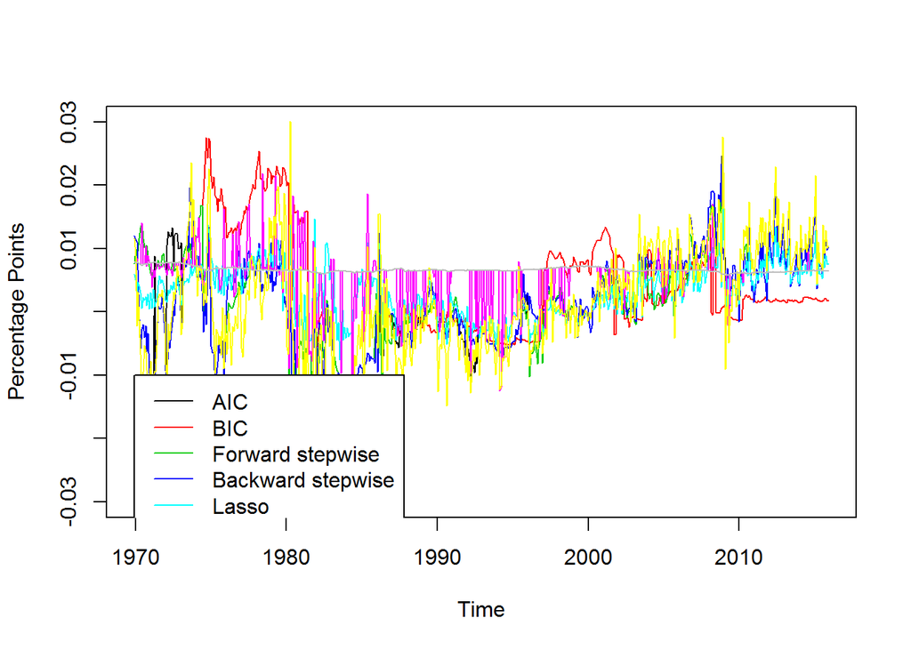

```r
timeVector = seq(1969+11/12,2015+11/12,length.out =  TT-estimationEnd)  #you need to change this
matplot(timeVector,forecasts,type = 'l',col=palette(),lty=1,xlab = 'Time',ylab = 'Percentage Points')
legend(min(timeVector),-0.01,modelLabels[-1],col=palette(),lty = rep(1,8))
```

### Part1

Looking at the Root mean Squared error, we deduce that Combination Forecast (which is the equal-weighted average of all model forecasts) produces best forecast with least RMSE.  
However if we consider models by AIC or BIC,LASSO and stepwise selection methods , we can see LASSO having the edge with least RMSE among them.

Here is the plot of actuals vs forecast for each of the methods .

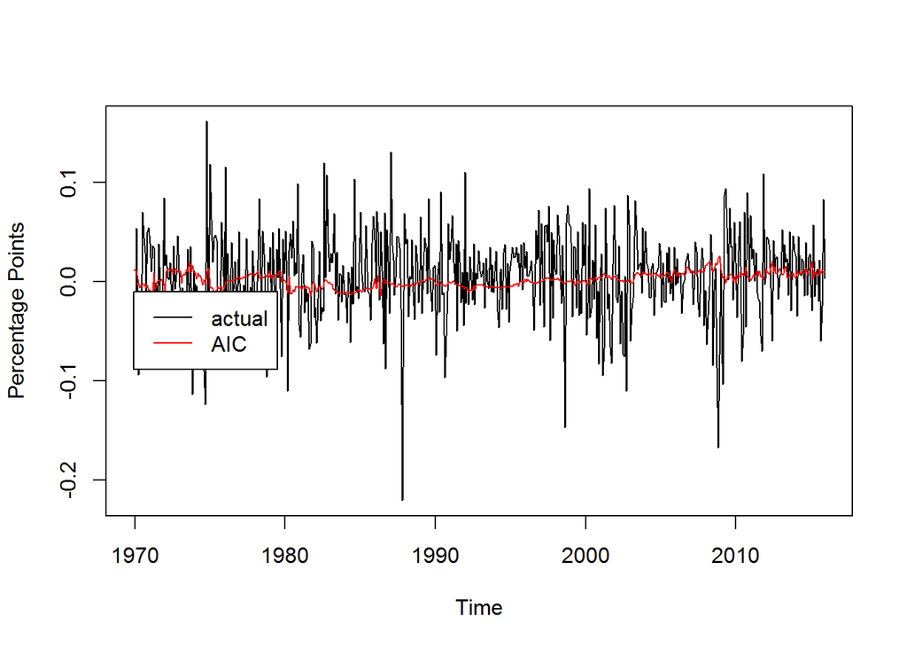

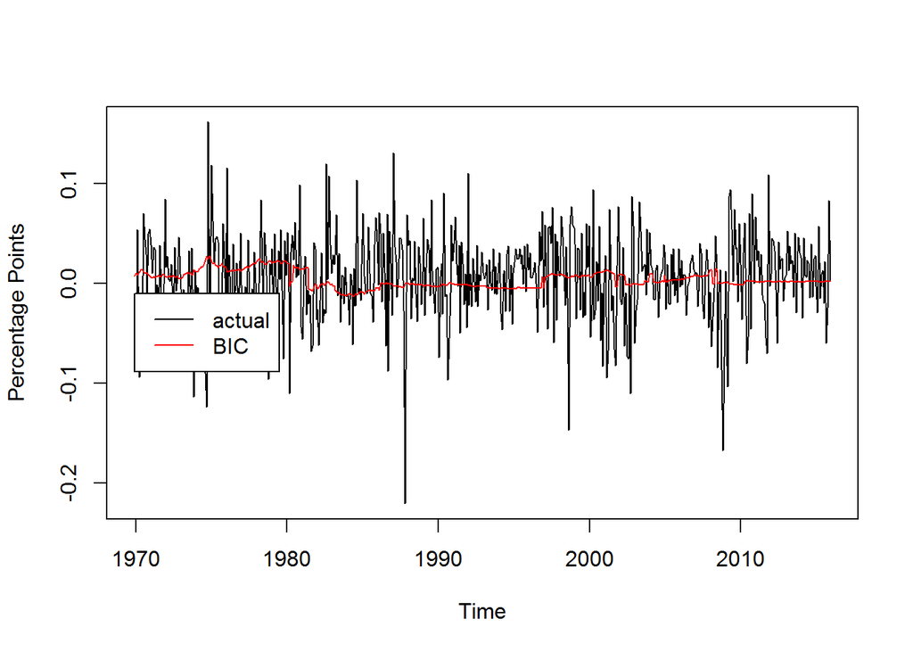

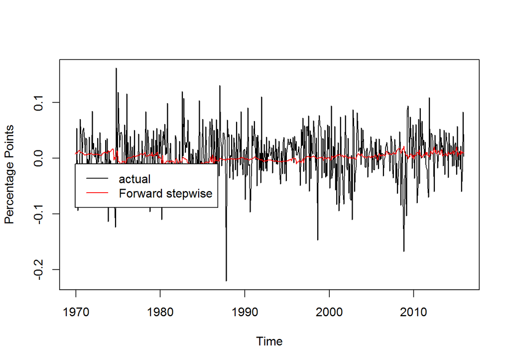

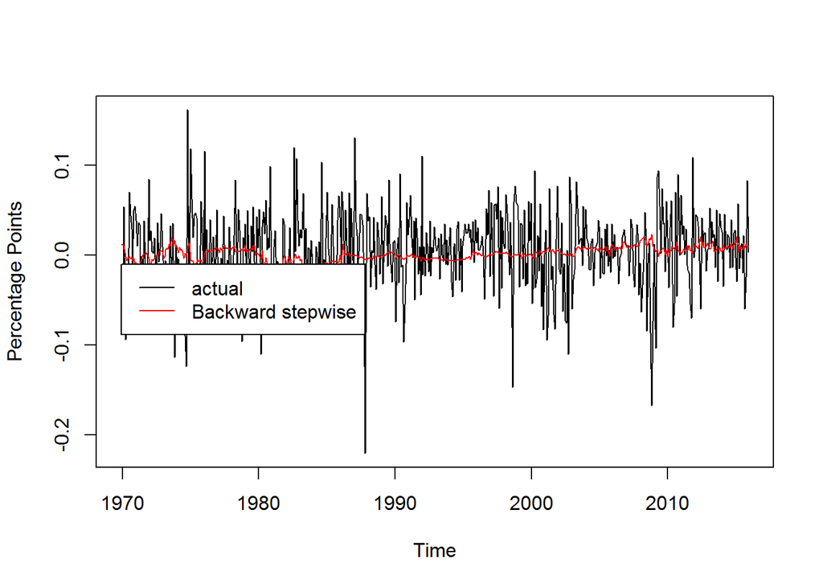

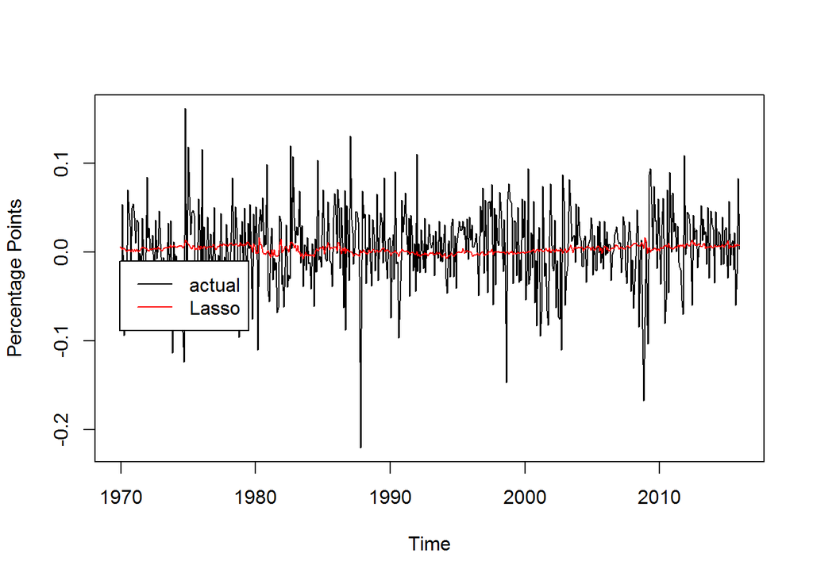

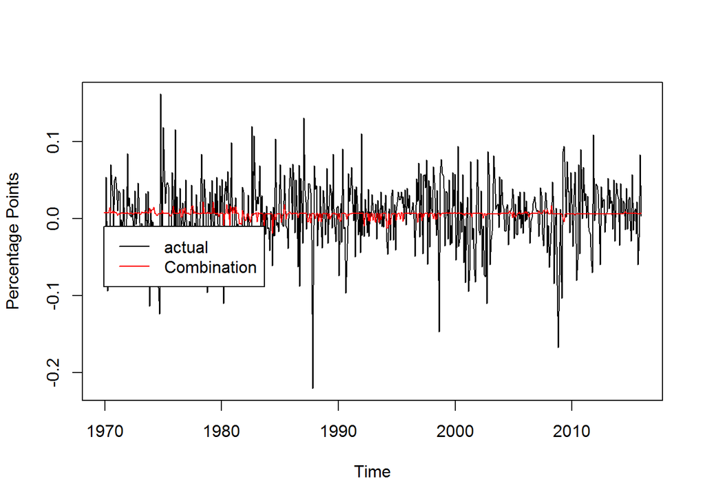

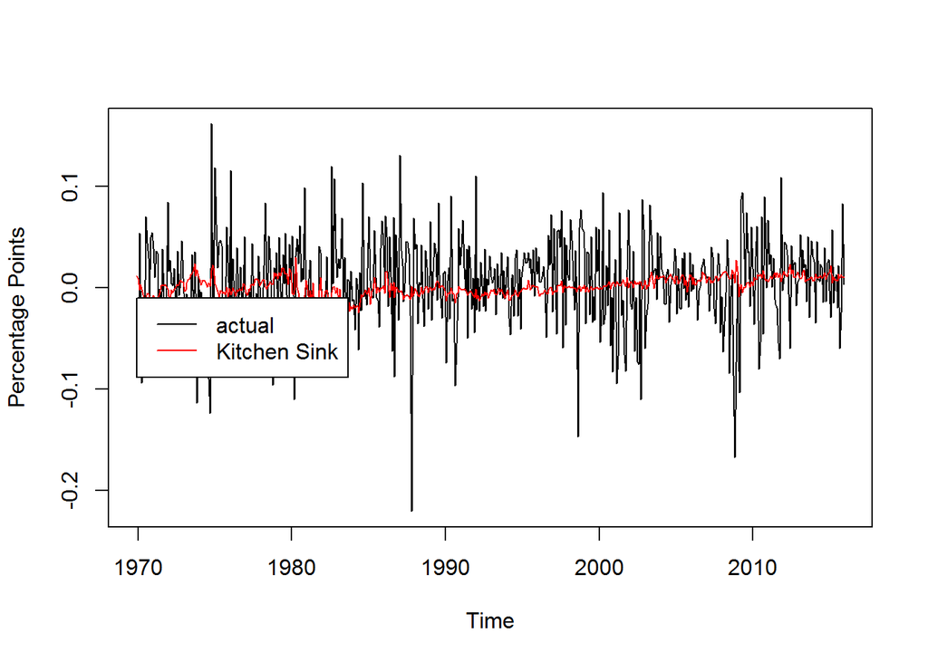

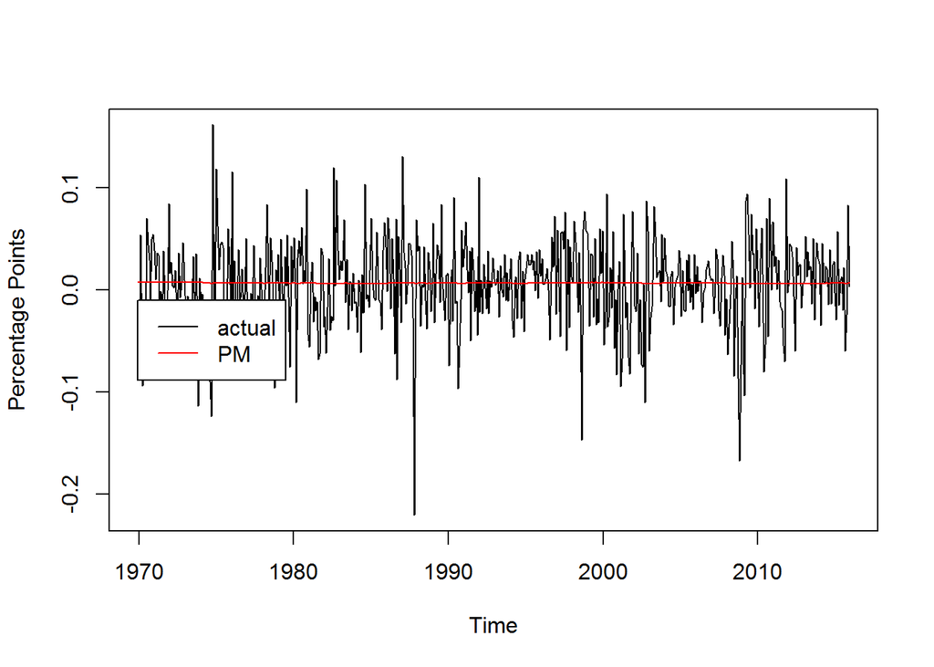

```r
for(i in (1:8)){
  #Plot model forecasts
  timeVector = seq(1969+11/12,2015+11/12,length.out =  TT-estimationEnd)  #you need to change this
  forecast.actual <- cbind(y[seq(estimationEnd,TT-1)],forecasts[,i])
  matplot(timeVector,forecast.actual,type = 'l',col=palette(),lty=1,xlab = 'Time',ylab = 'Percentage Points')
  forecast.actual.legend <- c("actual",modelLabels[-1][i])
  legend(min(timeVector),-0.01,forecast.actual.legend,col=palette(),lty = rep(1,2))
}
```

### Part2:

How often does your preferred model selection approach include different predictor variables?

```r
predictor.variables <- cbind(colnames(datas[seq(1,nrow(datas)),c(6:15)]),round(apply(predictors.model.lasso,2,mean)*100,2))
predictor.variables
```

```
##       [,1]               [,2]
##  [1,] "D.P"              "2.17"
##  [2,] "E.P"              "14.31"
##  [3,] "b.m"              "28.62"
##  [4,] "T.bill.rate"      "14.49"
##  [5,] "default.spread"   "0"
##  [6,] "long.term.yield"  "7.07"
##  [7,] "net.eq..issue"    "18.84"
##  [8,] "inflation"        "16.85"
##  [9,] "long.term.return" "14.86"
## [10,] "stock.variance"   "1.09"
```

### Part3:

Compute model RMSEs (root mean squared errors)

```r
RMSE = sqrt(colMeans(forecastsErrors^2))
RMSE
```

```
## [1] 0.04533025 0.04546949 0.04533935 0.04530623 0.04423316 0.04430255 0.04498754 0.04431838
```

LASSO model model produces better forecast with RMSE of 0.04431 when compared to the Prevailing mean model with RMSE of 0.04432

### Part4:

LASSO model model produces better forecast with RMSE of 0.04431 when compared to the Kitchen Sink model with RMSE of 0.04498

### Part5:

Calculate economic performance of models (relative to risk free rate)

```r
riskFree = datas[seq(1,nrow(datas)),17]
stockReturn = datas[seq(1,nrow(datas)),ncol(datas)-1]
economicReturns = matrix(0,nrow(forecasts),ncol(forecasts))
```

```r
for (ii in seq(1,ncol(forecasts))) {
  negativeReturns = forecasts[,ii]<=0
  economicReturns[,ii] = riskFree[seq(estimationEnd,TT-1)]*negativeReturns+stockReturn[seq(estimationEnd,TT-1)]*(!negativeReturns)
}
```

Compute mean returns and Sharpe Ratios

```r
meanReturns = colMeans(economicReturns)
meanReturns
```

```
## [1] 0.007441829 0.006543568 0.007543811 0.007357851 0.009302647 0.008877422 0.007790466 0.009225928
```

Compute mean returns and Sharpe Ratios

```r
sharpeRatios = (meanReturns-mean(riskFree[-seq(1,estimationEnd)]))/apply(economicReturns, 2, sd)
sharpeRatios
```

```
## [1] 0.10113813 0.06936037 0.10279868 0.09882297 0.13281532 0.11185438 0.10419858 0.11564359
```

Combination Forecast model generates highest mean Returns and Sharp Ratios.  
Among the three models discussed above Prevailing Mean model generates highest mean Returns and Sharp Ratios

### Part6:

Modern financial markets are big, fast, and dense. Predictability doesn’t always occur at scales that are easy for people to intuit. Hence we replace this intuition step with statistics and use selection operator (LASSO) (as well as other methods) to identify rare, short-lived, “sparse” signals in the cross-section of returns.  
Since LASSO is a penalized-regression technique that simultaneously identifies and estimates the most important coefficients by betting on sparsity-that is, by assuming only a handful of variables actually matter at any point in time.This is the reason in this case why LASSO has performed well compared to other models like stepwise, AIC and BIC.  
In addition to that it is difficult to predict returns over short time periods say over the next few days or weeks in an accurate manner. This is quite evident when we look at the actual vs forecast plots, but it is quite possible to foresee the broad course of these prices over longer periods, such as the next three to five years.Even averages perform better than predictions modeled on expected selected predictors. While the fit of the model is positive, out of sample forecasts can be quite off.